# Overlapping generations models

**NOTE**: The present notebook is coded in R. It relies heavily on the [**tidyverse**](https://www.tidyverse.org/) ecosystem of packages. We load the tidyverse below as a prerequisite for the rest of the notebook - along with a few other libraries.

$\rightarrow$ Don’t forget that code flows **sequentially**. A random chunk may not work if the previous have have not been executed.

```r
library(tidyverse)   # Package for data wrangling
library(purrr)       # Package for functional programming
library(readxl)      # Package to import MS Excel files
library(latex2exp)   # Package for LaTeX expressions
library(quantmod)    # Package for stock data extraction
library(highcharter) # Package for reactive plots
library(ggsci)       # Package for color palettes
```

The content of the notebook is heavily inspired from the book [**Advanced Macro-economics - An Easy Guide**](https://press.lse.ac.uk/site/books/m/10.31389/lsepress.ame/).

# Context

Generations are linked in multiple fashions:

- An obvious example is the **environment**: as the saying goes, “*we do not inherit the earth from our ancestors; we borrow it from our children*”.
- Another example (especially in French politics) pertains to **fiscal policy** and **the burden of debt** (who should carry it).
- Finally, a last illustration is the **transmission of knowledge**. Shifting economic needs and to much reliance on technological change can lead to a loss of skills and know-how.

# Models

## Chronological setup

Time $t$ is discrete here (but could be continuous, leading to different developments). Each generation lives through two phases only: **work** and **retirement** (children don’t count!).

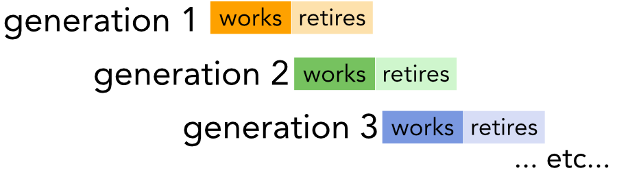

In the baseline model this won’t have too many implications in fact (at least in terms of differences between generations).

## Individuals

The population is such that there are $L_t=L_0(1+n)^t$ individuals born at time $t$. Agents born at time $t$ maximize the following utility function based on **consumption** (note, this is a two-period setup):

$$\left(\frac{\sigma}{\sigma-1} \right)\left(c_{t, \text{work}}^{1-1/\sigma} + \frac{1}{1+\rho}c_{t+1, retire}^{1-1/\sigma}\right), \tag{1}$$

where $\rho$ is the **discounting rate** (preference over time) and $\sigma$ controls **risk aversion**. Equation 1 is optimized under the following constraints:
$$w_t = c_{t, \text{work}}+ s_t , \tag{2}$$
that is: the wage $w_t$ at time $t$ is spent either in **consumption** or in **savings** $s_t$, as well as:
$$c_{t+1, \text{retire}}=(1+r_{t+1})s_t, \tag{3}$$
that is: upon retirement, the agent can only consume what he has saved (invested in a product that delivers a rate of $r_{t+1}$, which is the **rental rate of capital**: what you get from lending money to the firm so that it can invest for production purposes).

Replacing $c_{t+1,retire}$ and $s_t$ from the constraints, we get that the first order condition is

$$\frac{\partial}{\partial c_{t,\text{work}}} \left(\left(\frac{\sigma}{\sigma-1} \right)\left(c_{t, \text{work}}^{1-1/\sigma} + \frac{1}{1+\rho}((1+r_{t+1})(w_t-c_{t,\text{work}}))^{1-1/\sigma}\right) \right)=0$$
i.e., (again keeping in mind the value of $c_{t+1, retire}$):
$$c_{t, \text{work}}^{-1/\sigma}-\frac{1+r_{t+1}}{1+\rho}c_{t+1,\text{retire}}^{-1/\sigma}=0.$$

**NoteThis simplifies to**

$$\frac{c_{t+1, \text{retire}}}{c_{t,\text{work}}}=\left(\frac{1+r_{t+1}}{1+\rho} \right)^{\sigma},$$
which can be viewed as the **Euler equation** for the generation “*born*” at time $t$.

If we divide Equation 3 by $c_{t,work}$ in Equation 2, we also get the same ratio, hence

$$\frac{(1+r_{t+1})s_t}{w_t- s_t}=\left(\frac{1+r_{t+1}}{1+\rho} \right)^{\sigma} \ \Leftrightarrow \ s_t=w_t\left(\frac{1}{1+(1+\rho)^{\sigma}(1+r_{t+1})^{1-\sigma}}\right). \tag{4}$$
This is the **savings function** and it is proportional to the **income**. All quantities in the denominator are positive, hence the ratio $s_t/w_t$ is smaller than one.

**TipDiscussion on $\rho$ and $r$**

In most of what we covered so far, the time step is usually the year, for simplicity.  
Here, because we are talking about **generations**, the lag can be substantially larger, for instance 30 years. Hence, the parameter values should reflect this. When we imagined $\rho=5\%$, over 30 years, this makes $\rho \approx 330\%$! Same for returns, if we imagine an annual rate of 4%, then $r=225\%$…

It’s important to keep this in mind for numerical applications.

## Firms

**TipWe assume:**

- a simple production function with **constant returns to scale**, hence the model is mainly defined by the output per worker: $y=f(k)$, with $k$ being the capital/labor ratio.
- that these firms rent capital until the marginal product of capital is equal to the lending rate of capital. The reason for this is that we can set the (per-worker CRS) **profit function** to $\pi(k)=f(k)-r_{t}k$ (production minus cost of capital), hence the FOC is
  $$f'(k)=r_t. \tag{5}$$
- that firms also equate the marginal product of labor to its **cost**, $w_t$: $\pi(L)= Lf(K/L)- w_tL$, hence $\frac{\partial \{Lf(K/L)- w_tL\}}{\partial L}=f(k) -LK \frac{f'(K/L)}{L^2}-w_t=0$ implies
  $$f(k_t)-k_tf'(k_t)=w_t. \tag{6}$$
- finally, that the capital available at time $t+1$ is equal to the **total savings of the young generation** (the old generation is retired so it only consumes). Hence:
  $$K_{t+1}= L_ts_t \ \Leftrightarrow \ s_t = (1+n)k_{t+1} \tag{7}$$

**Important**

Because of this last expression, most of the focus in what comes next is on **savings**. Indeed:
$$\text{savings} \rightarrow \text{capital} \rightarrow \text{production (in CRS model)}$$

The focus is to understand the effort (of the young generation) that is required to keep the system going.

## A tractable example

### The model

As usual, let’s consider a Cobb-Douglas production function: $y=k^\alpha$ with $\alpha \in (0,1)$, and log-preferences ($\sigma=1$). This yields that the savings are simply equal to
$$s_t=(2+\rho)^{-1} w_t.$$

Interestingly, the interest rate has disappeared from the expression (this comes from the myopic log-utility). From Equation 5, we get
$$r_t = \alpha k_t^{\alpha-1},$$
and from Equation 6,
$$w_t = k_t^{\alpha}(1-\alpha) = (1-\alpha)y_t,$$

so that the wage is a **fraction of the per-worker production**. The link between capital and savings from Equation 7 then allows to write:
$$k_{t+1}=\frac{s_t}{1+n}=\frac{w_t}{(1+n)(2+\rho)}=\frac{(1-\alpha)k_t^\alpha}{(1+n)(2+\rho)}. \tag{8}$$

**NoteThe solution**

Hence, the **steady-state** capital that verifies $k^*=k_t=k_{t+1}$ is
$$k^*=\left( \frac{1-\alpha}{(1+n)(2+\rho)} \right)^{1/(1-\alpha)} \ \Rightarrow y^* = \left( \frac{1-\alpha}{(1+n)(2+\rho)} \right)^{\alpha/(1-\alpha)}.$$
Both quantities are **decreasing** in $n$ and $\rho$. If the population grows faster, the optimal ratio $K/L$ decreases. If the discounting rate increases, the optimal $k$ also decreases because **optimal savings**, too, would be lower.

Moreover, we can derive the steady-state **interest rate**:
$$r^* = f'(k^*)= \frac{\alpha}{1-\alpha}(2+\rho)(1+n),$$
which increases with all parameters.

With reasonable parameter values, what kind of rate does this imply?

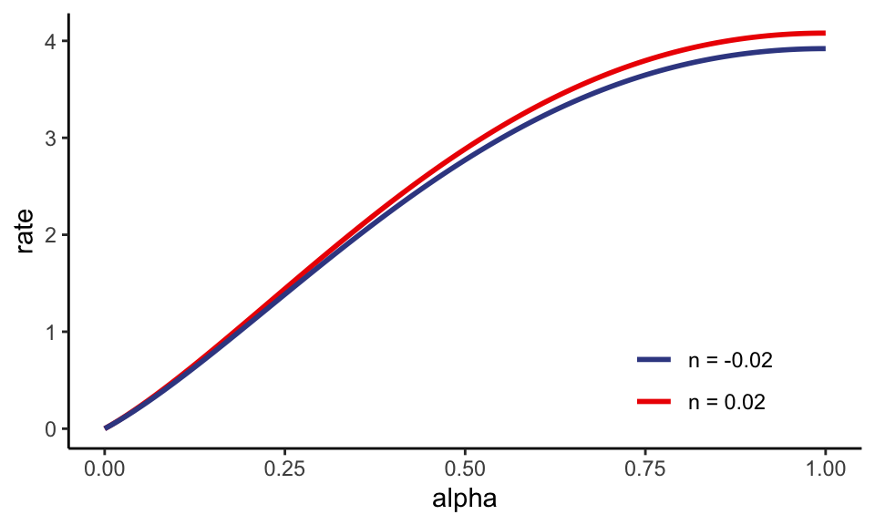

```r
rho <- 2
n <- 0.02
ggplot() + xlim(c(0, 1)) +
  geom_function(fun = ~ (.x)^(1-.x)*(2+rho)*(1+n),
                size = 1, aes(color = paste("n =", n))) +
  geom_function(fun = ~ (.x)^(1-.x)*(2+rho)*(1-n),
                size = 1, aes(color = paste0("n = -", n))) +
  theme_classic() + xlab("alpha") + ylab("rate") +
  scale_color_aaas(name = "") +
  theme(legend.position = c(0.8,0.2))
```

These values are plausible for $\alpha > 0.1$ only in a **long-term** perspective.  
Also, the curves are not too sensitive to $n$ (makes sense, given the formula, but surprising in spirit).

### Convergence to the steady state

We have that
$$k_{t+1}=\frac{s_t}{1+n}=\frac{s(w_t,r_{t+1})}{1+n} =\frac{s(f(k_t)-k_tf'(k_t), f'(k_{t+1}))}{1+n}$$
because the saving rate $s_t$ depends both on $w_t$ and on $r_{t+1}$ and both depend on $k$ via Equation 6 and Equation 5. Hence,
$$(1+n)\frac{\partial k_{t+1}}{\partial k_t}= \frac{\partial s}{\partial w}\frac{\partial w}{\partial k_t}+\frac{\partial s}{\partial r}\frac{\partial r}{\partial k_t}$$
Hence,
$$(1+n)\frac{\partial k_{t+1}}{\partial k_t}= s_w \times (f'(k_t)-f'(k_t)-k_tf''(k_t)) + s_r \times f''(k_{t+1})\frac{\partial k_{t+1}}{\partial k_t}$$
so that, gathering the pieces,
$$\frac{\partial k_{t+1}}{\partial k_t} = \frac{-s_w(k_t) k_tf''(k_t)}{1+n-s_r(k_{t+1})f''(k_{t+1})},$$
and basically, we want this quantity to be smaller than one in absolute value so that the system does not explode.

## Numerical simulations

In all generality, it is impossible to simulate the model because the variation $\frac{\partial k_{t+1}}{\partial k_t}$ depends on $k_{t+1}$! This is because of the savings rate which appears everywhere with its time index at $t+1$.

However, as we have seen in the previous example with Cobb-Douglas production and logarithmic utility, $r_{t+1}$ vanishes from the expression of $k_{t+1}$ in Equation 8.

So let’s give it a try… (with short-term parameter values)

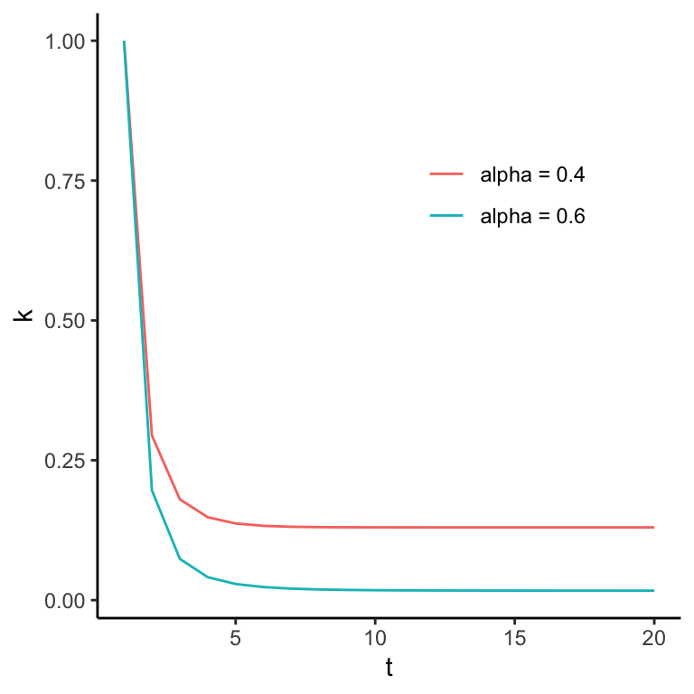

```r
rho <- 0.02
n <- 0.01
alpha <- 0.5
n_periods <- 20
k_star <- function(alpha, rho, n){
  k <- 1
  for(i in 2:n_periods){
    k[i] <- k[i-1]^alpha * (1-alpha)/(2+rho)/(1+n)
  }
  k
}

ggplot() +
  geom_line(data = tibble(t = 1:n_periods, k = k_star(0.4, 0.02, 0.01)),
            aes(x = t, y = k, color = "alpha = 0.4")) +
  geom_line(data = tibble(t = 1:n_periods, k = k_star(0.6, 0.02, 0.01)),
            aes(x = t, y = k, color = "alpha = 0.6")) +
  theme_classic() +
  theme(legend.position = c(0.7, 0.7),
        legend.title = element_blank())
```

We do achieve convergence (and quite rapidly).

# Overlapping generations and pension systems

**Generational solidarity** is at the heart of some pension systems, at least this is the case in France. The elderly depend on the younger workers to pay for their income. In some countries (e.g., the US), this is less the case and each individual must save throughout his/her entire active/working life and then rely on savings upon retirement. This is a challenge potentially, as it requires a crucial unknown information: the time of death! [Pension schemes](https://www.gov.uk/pension-types) can be complex and subject to debate.

## The model

### Setup

We write:

- $d_t$ for the **contribution** of a young worker at time $t$;
- $b_t$ the the **benefits** received by an old retiree at time $t$.

For simplicity, we assume only two periods, as before.

**NoteWe want to compare two systems:**

- **pay-as-you go**: the young (working) generations are “taxed” to pay for future retirement benefits (ex: France). In this case,
  $$b_t=(1+n)d_t \tag{9}$$
  The $(1+n)$ term reflect the potential **difference in population sizes**. If the population grows ($n>0$), then there are more active workers than retirees and the latter can comfortably benefit from a larger benefit. Otherwise (where many developed countries are headed), it’s more complicated!(see below)
- **fully funded**: the young must save on their own and can consume upon retirement to proceedings of their savings (ex: the United States). Then, straightforwardly,
  $$b_{t+1}= (1+r_{t+1})d_t. \tag{10}$$

### Consumption & savings

As in the simplified model above, the agents’ problem is to maximize
$$\log(c_{\text{young}, t})+\frac{\log(c_{\text{old}, t+1})}{1+\rho},$$
under the constraints:
$$c_{\text{young},t}+s_t+d_t=w_t \tag{11}$$
and
$$c_{\text{old}, t+1}=(1+r_{t+1})s_t+b_{t+1}. \tag{12}$$
The first is the use of income (wage): **consumption**, **savings** and **contribution**. The second shows where the money comes from: either **savings**, or the **pension benefits**.

The FOC remains:
$$c_{\text{old}, t+1}=\frac{1+r_{t+1}}{1+\rho}c_{\text{young}, t}.$$

Then, plugging Equation 11 and Equation 12 in the FOC equation, we get
$$(1+r_{t+1})s_t+b_{t+1}=\frac{1+r_{t+1}}{1+\rho}(w_t-s_t-d_t),$$
and factoring out the savings, we get
$$s_t=\frac{(1+r_{t+1})(w_t-d_t)-b_{t+1}(1+\rho)}{(1+r_{t+1})(2+\rho)}. \tag{13}$$

Savings **increase with income** (as expected), but **decrease with contributions** and (future) benefit. As before, with Cobb-Douglas production, $r_t=\alpha k_t^{\alpha -1}$ and $w_t=(1-\alpha)y_t$.

## Implications for pensions schemes

### Digression on $n$ (population growth)

One important parameter that is sometimes overlooked is $n$. In the model, it measures the relative size change between active workers (young generation) versus retirees (old generation). Let’s have a look at what the data says…

```r
library(tidyverse)    # Package for data wrangling
library(readxl)       # Package to import MS Excel files
library(WDI)          # To access World Bank data
library(ggsci)        # Color scales
library(plm)          # Panel models
```

We extract the data from the **World Bank**, as usual, with some new fields.

```r
wb_labor <- WDI(                                   # World Bank data
  indicator = c(
    "labor" = "SL.TLF.TOTL.IN",                    # Labor force (# of individuals)
    "pop" = "SP.POP.TOTL",                         # Population
    "pop_growth" = "SP.POP.GROW",                  # Population growth
    "pop_65_percent" = "SP.POP.65UP.TO.ZS",        # Population > 65yo (%)
    "age_dep_ratio" = "SP.POP.DPND"                # Age dependency ratio
  ),
  extra = TRUE, start = 1960, end = 2025) |>
  mutate(across(everything(), as.vector)) |>
  select(-status, -lending, -iso2c, -iso3c) |>
  filter(lastupdated == max(lastupdated)) |>
  arrange(country, year)

wb_labor <- wb_labor |> filter(region != "Aggregates") # Remove continents & co.
```

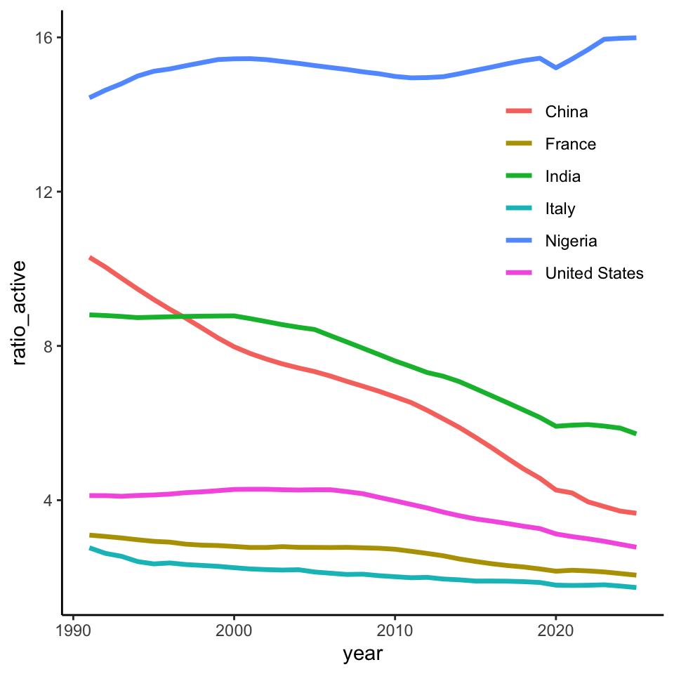

```r
wb_labor |>
  mutate(ratio_active = 100 * labor / (pop_65_percent) / pop) |>
  filter(country %in% c("France", "Italy", "United States", "India", "China", "Nigeria"),
         year > 1990) |>
  ggplot(aes(x = year, y = ratio_active, color = country)) + geom_line(linewidth = 1.2) +
  theme_classic() +
  theme(legend.position = c(0.85,0.70),
        legend.title = element_blank())
```

The ratio of active-to-retired is **shrinking** for most economies.  
This means that in pay-as-you-go systems, this will:

- either put more pressure on the working share of the population; or
- reduce the benefits of retirees (hard to sell - there is a “social contract”)

### The fully-funded system

We just need to plug Equation 10 into Equation 13 to get
$$s_t=\frac{w_t}{2+\rho} - d_t.$$
Hence, there is a one-to-(minus)one relationship between savings and contribution. Each unit that is contributed is subtracted from savings. Here, there is only one interest rate for savings and the agent does not care where the benefits will come from.

**Important**

### Pay-as-you-go

If we however insert Equation 9 into Equation 13, the expression is more involved:

$$s_t = \frac{w_t}{2+\rho} - \frac{(1+r_{t+1})d_t+(1+\rho)(1+n)d_{t+1}}{(2+\rho)(1+r_{t+1})}. \tag{14}$$
To ease interpretation, we can assume a constant contribution $d_{t+1}=d_t=d$:

$$s_t=\frac{w_t}{2+\rho} - d \frac{(1+r_{t+1}) + (1+\rho)(1+n)}{(2+\rho)(1+r_{t+1})} \tag{15}$$

In this case, each unit of contribution reduces savings by $\frac{(1+r_{t+1}) + (1+\rho)(1+n)}{(2+\rho)(1+r_{t+1})}$. How big is this figure compared to one (the fully-funded benchmark)? Let’s try to calibrate with simple values: with $r_{t+1}=2.4$, $\rho=3$, $n=0.0$ (zero population growth), we get a (derivative) value of $\approx 0.435$, which is well below the fully-funded one.

## Shifting from PAYG to FF

With the ratio of working-to-retired population growing thinner in most economies, the **burden of contributions** in PAYG systems is becoming unbearable for the younger generations. Hence, a shift towards hybrid or pure fully-funded systems seems unavoidable. But what kind of transition does this imply, and how can it be funded?

### Taxing the young

Obviously, the retired no longer have income, hence funding can only come from the young. In this case, their income is split as follows
$$w_t=c_{\text{young}, t} + s_t+d+\tau_t, \tag{16}$$

- **consumption**;
- standard **savings**;
- **contribution** (for retirement);
- new **tax** (to fund the transition).

Future consumption upon retirement will be

$$c_{\text{old}, t+1} = (1+r_{t+1})s_t + (1+r_{t+1})d = (1+r_{t+1})(s_t+d).$$

Combined with the Euler equation $c_{\text{old},t+1}=\frac{1+r_{t+1}}{1+\rho}c_{\text{young},t}$, the above equation implies $s_t+d=\frac{c_{\text{young},t+1}}{1+\rho}$. Plugging $c_{\text{young},t}$ in Equation 16:
$$w_t = (1+\rho)(s_t+d)+s_t+d+\tau_t=(2+\rho)(s_t+d)+\tau_t$$
Aggregate savings are then equal to
$$s_t+d = \frac{w_t-\tau_t}{2+\rho}.$$

If we assume zero population growth ($n=0$) in Equation 15, it can be shown ($\rightarrow$ exercise!) that this quantity is higher than in the PAYG system of Equation 14 (setting $\tau_t=d$: taxes are 100% used to fund the older generation).

### Issuing debt

Taxing the young is not a socially acceptable solution. Resorting to debt seems more reasonable:

$$w_t = c_{\text{young},t} + s_t + d + g_{\text{debt}},$$
where $g_{\text{debt}}$ is an external asset that the young generation can buy. In this case, the consumption of retirees becomes
$$c_{\text{old},t+1}= (1+r_{t+1})s_t + (1+r_{t+1})d + (1+r_{t+1})g_{\text{debt}}$$
and **total savings** are now:
$$s_t+d = \frac{w_t}{2+\rho}-g_{\text{debt}} = \frac{w_t}{2+\rho}-d,$$
which is lower than Equation 14 when $r>n$. Hence this seems like a pleasant solution (politically speaking)!

# Other applications

The pension system is only one application of overlapping generations models. Their main advantage is that they make it possible to study how decisions made today affect people who belong to different generations.

## Climate change

Climate change is a natural application because current generations choose consumption, saving, and emissions, while future generations **inherit** the resulting climate and capital stock. In the influential model of [John and Pecchenino (1994)](https://ideas.repec.org/a/ecj/econjl/v104y1994i427p1393-1410.html), environmental quality evolves according to
$$E_{t+1}=(1-\delta)E_t-\beta c_t+\gamma m_t, \tag{17}$$
where $m_t$ is maintenance or abatement. A simple budget constraint is
$$w_t=c_t+s_t+m_t. \tag{18}$$
Current consumption **reduces** the environmental quality inherited by the next generation, while **maintenance** improves it. This framework can therefore study the distribution of climate policy costs across cohorts. For a recent survey of environmental OLG models, see [Dugan, Prskawetz, and Raffin (2024)](https://doi.org/10.1111/joes.12602).

## Knowledge transmission (and AI)

Recent work connects this idea directly to artificial intelligence. In [Automation, AI, and the Intergenerational Transmission of Knowledge](https://arxiv.org/html/2507.16078), workers first enter the labor market as novices and later become experts. Novices acquire **tacit knowledge** by working alongside experts. If $F_t(q)$ is the distribution of expert skills ($q$is the skill level), $a_t$ is the marginal active skill, and $N-I$ is the number of **novices** hired by each **expert**, the law of motion is
$$F_{t+1}(q)=\begin{cases}0 & \text{if } q\leq a_t,\\(N-I)\left[F_t(q)-F_t(a_t)\right] & \text{if } q>a_t.\end{cases} \tag{19}$$
Only experts with skill above $a_t$ are active mentors. The next generation therefore inherits the skills of its mentors. The model makes the career ladder a genuine **transmission** mechanism.

Suppose that an AI improvement automates an additional $\Delta$ tasks, with machine productivity $m$, novice productivity $h$, and tail parameter $\theta$. Let $Y_t$ denote aggregate output at date $t$ without the AI shock, $\widetilde{Y}_t$ be the aggregate output at date $t$ after the shock, which occurs at date $\tau$. Ide derives the **output ratio** comparing these two quantities:
$$\frac{\widetilde{Y}_t}{Y_t}=\underbrace{\left(\frac{m}{h}\right)^{\Delta}\left(1-\frac{\Delta}{N-I}\right)^{-(1-\theta)}}_{\text{immediate adoption gains}}\underbrace{\left(1-\frac{\Delta}{N-I}\right)^{\theta(t-\tau)}}_{\text{long run losses}}. \tag{20}$$
The first term captures productivity gains upon adoption, while the second may reduce future growth. If AI removes junior tasks, fewer novices may learn from the most productive experts, so the economy **loses a share of competences** needed by future cohorts.

This mechanism relates to recent evidence. [Brynjolfsson, Chandar, and Chen (2026)](https://siepr.stanford.edu/publications/working-paper/canaries-coal-mine-six-facts-about-recent-employment-effects-artificial) document a relative decline in employment for workers aged 22 to 25 in highly AI exposed occupations, while employment among experienced workers remains more stable. [Hosseini and Lichtinger (2025)](https://doi.org/10.2139/ssrn.5425555) find a similar seniority pattern within AI adopting firms. These results are descriptive (not causal), but they corroborate the possibility that AI can (will?) weaken the entry level positions through which tacit knowledge is transmitted.